# Week46 Lecture4

562770bf

2024-11-14

This is the second Readme file for the Data Science and HR analytics course, trying out experiments on the code for lecture 4.

So let’s get started.

```r
SC <- read.csv("/Users/annelies2/Downloads/semiconductor.csv")
full <- glm(FAIL ~ ., data=SC, family=binomial)
1 - full$deviance/full$null.deviance
```

```
## [1] 0.5621432
```

Running this formula will give you an indication of how much your predictors (variables in the semiconductor dataset) improve the model’s ability to predict the outcome, FAIL (whether or not a semiconductor failed). A higher R² indicates better model performance in terms of explaining the failure.

```r
deviance <- function(y, pred, family=c("gaussian","binomial")){
family <- match.arg(family)
if(family=="gaussian"){
return( sum( (y-pred)^2 ) )
}else{
if(is.factor(y)) y <- as.numeric(y)>1
return( -2*sum( y*log(pred) + (1-y)*log(1-pred) ) )
}
}
## get null devaince too, and return R2
R2 <- function(y, pred, family=c("gaussian","binomial")){
fam <- match.arg(family)
if(fam=="binomial"){
if(is.factor(y)){ y <- as.numeric(y)>1 }
}
dev <- deviance(y, pred, family=fam)
dev0 <- deviance(y, mean(y), family=fam)
return(1-dev/dev0)
}
# setup the experiment
n <- nrow(SC) # the number of observations
K <- 10 # the number of `folds'
# create a vector of fold memberships (random order)
foldid <- rep(1:K,each=ceiling(n/K))[sample(1:n)]
# create an empty dataframe of results
Out <- data.frame(full=rep(NA,K))
# use a for loop to run the experiment
for(k in 1:K){
train <- which(foldid!=k) # train on all but fold `k'
## fit regression on full sample
rfull <- glm(FAIL~., data=SC, subset=train, family=binomial)
## get prediction: type=response so we have probabilities
predfull <- predict(rfull, newdata=SC[-train,], type="response")
## calculate and log R2
Out$full[k] <- R2(y=SC$FAIL[-train], pred=predfull, family="binomial")
## print progress
cat(k, " ")
}
```

```
## 1
```

```
## 2
```

```
## 3
```

```
## 4
```

```
## 5
```

```
## 6
```

```
## 7
```

```
## 8
```

```
## 9
```

```
## 10
```

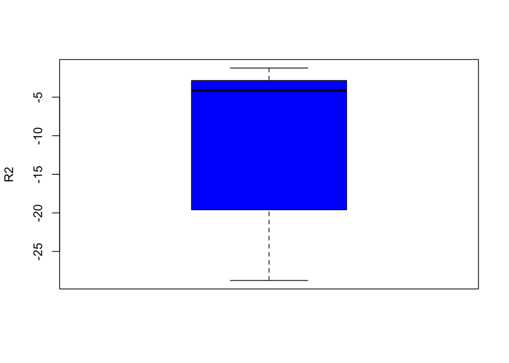

```r
boxplot(Out, col="blue", ylab="R2")
```

```r
colMeans(Out)
```

```
##      full
## -10.63385
```

This code performs 10-fold cross-validation on a logistic regression model using the semiconductor dataset. It calculates McFadden’s R² for each fold to assess model performance. The deviance function measures model fit, while the R² function compares the model to a null model. After running the cross-validation, the results are visualized with a boxplot.

A negative McFadden’s R² usually suggests the model is not fitting the data well, and perhaps further model improvements or more relevant predictors are needed. It’s common in situations where the predictors do not have enough predictive power or if the model is overfitting.

```r
#Experiment
# Create additional columns for R2 values with gaussian family
Out$gaussian <- rep(NA, K)

# Loop over folds for both binomial and gaussian families
for (k in 1:K) {
  train <- which(foldid != k) # Train on all but fold 'k'

  # Fit regression using binomial family
  r_binomial <- glm(FAIL ~ ., data=SC, subset=train, family=binomial)
  pred_binomial <- predict(r_binomial, newdata=SC[-train,], type="response")
  Out$full[k] <- R2(y=SC$FAIL[-train], pred=pred_binomial, family="binomial")

  # Fit regression using gaussian family
  r_gaussian <- glm(FAIL ~ ., data=SC, subset=train, family=gaussian)
  pred_gaussian <- predict(r_gaussian, newdata=SC[-train,])
  Out$gaussian[k] <- R2(y=SC$FAIL[-train], pred=pred_gaussian, family="gaussian")

  # Print progress
  cat(k, " ")
}
```

```
## 1
```

```
## 2
```

```
## 3
```

```
## 4
```

```
## 5
```

```
## 6
```

```
## 7
```

```
## 8
```

```
## 9
```

```
## 10
```

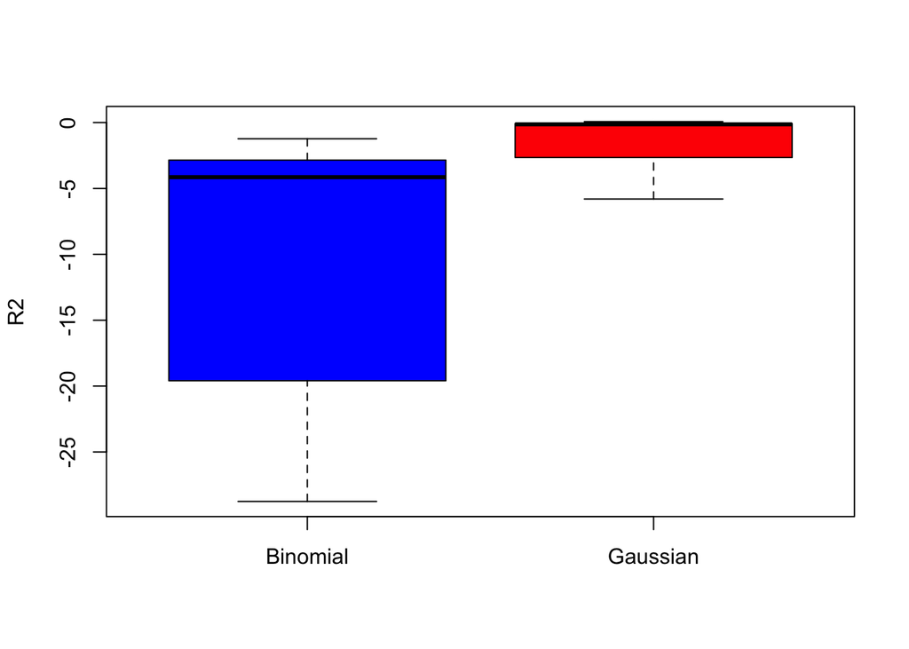

```r
# Compare R2 values for the two families
# Corrected boxplot call
boxplot(Out[, c("full", "gaussian")],
        col=c("blue", "red"),
        ylab="R2",
        names=c("Binomial", "Gaussian"))
```

The experiment compares the performance of different families (gaussian vs. binomial) for the response variable to investigate whether the data structure benefits more from one approach over the other.

The Gaussian model appears to perform better or more consistently than the Binomial model, at least in terms of R^2. However, neither model seems to fit the data particularly well, given that R^2 is generally expected to be positive for a good fit.

```r
null <- glm(FAIL~1, data=SC)
fwd <- step(null, scope=formula(full), dir="forward")
```

[output not shown]

[output cut: 12108 more lines]

```
## + SIG36   1   74.554 -77.147
## + SIG55   1   74.554 -77.147
## + SIG183  1   74.554 -77.140
## + SIG6    1   74.554 -77.138
## + SIG143  1   74.554 -77.138
## + SIG120  1   74.554 -77.134
## + SIG157  1   74.555 -77.123
## + SIG26   1   74.555 -77.122
## + SIG112  1   74.555 -77.122
## + SIG19   1   74.555 -77.122
## + SIG121  1   74.555 -77.122
## + SIG87   1   74.555 -77.122
## + SIG70   1   74.555 -77.121
## + SIG158  1   74.555 -77.121
## + SIG123  1   74.555 -77.121
```

This code performs a forward stepwise selection, starting with a null model (only intercept) and iteratively adding predictors from the `full` model to improve the fit, selecting the best model based on statistical criteria like AIC.

[output not shown]

[output cut: 46 more lines]

[output not shown]

[figure not shown]

To conduct the experiment, you can modify your matrix xweb by introducing a new variable like visit_time, which would represent the time spent on each site. You would then run the gamlr model again using the new matrix, compare the results, and check whether the addition of this variable improves the model’s predictive power.

```r
# Experiment
# Add a new variable for time spent on each site (you can create this by multiplying visits by time per visit)
# For demonstration, let's assume a random time spent between 1 to 10 minutes on each site
set.seed(42) # for reproducibility
web$visit_time <- sample(1:10, nrow(web), replace = TRUE)

# Recompute the sparse matrix to include time spent
visit_time_percent <- 100 * web$visit_time / machinetotals[web$id]  # Calculate visit time percentages

# Create the new sparse matrix with time spent
xweb_time <- sparseMatrix(
    i = as.numeric(web$id), j = as.numeric(web$site), x = visit_time_percent,
    dims = c(nlevels(web$id), nlevels(web$site)),
    dimnames = list(id = levels(web$id), site = levels(web$site))
)

# Check the new matrix (just a sample of visits for the first machine)
head(xweb_time[1, xweb_time[1,] != 0])
```

```
## [1] 10
```

```r
# Run the gamlr model with the new matrix that includes time spent
spender_time <- gamlr(xweb_time, log(yspend), verb = TRUE)
```

[output not shown]

[output cut: 46 more lines]

```
## segment 86: lambda = 0.0081, dev = 0.0002622, npass = 3
## segment 87: lambda = 0.007732, dev = 0.0002389, npass = 3
## segment 88: lambda = 0.00738, dev = 0.0002177, npass = 3
## segment 89: lambda = 0.007045, dev = 0.0001984, npass = 3
## segment 90: lambda = 0.006725, dev = 0.0001807, npass = 3
## segment 91: lambda = 0.006419, dev = 0.0001647, npass = 3
## segment 92: lambda = 0.006127, dev = 0.0001501, npass = 3
## segment 93: lambda = 0.005849, dev = 0.0001367, npass = 3
## segment 94: lambda = 0.005583, dev = 0.0001246, npass = 3
## segment 95: lambda = 0.005329, dev = 0.0001135, npass = 3
## segment 96: lambda = 0.005087, dev = 0.0001034, npass = 3
## segment 97: lambda = 0.004856, dev = 9.424e-05, npass = 3
## segment 98: lambda = 0.004635, dev = 8.587e-05, npass = 3
## segment 99: lambda = 0.004424, dev = 7.824e-05, npass = 3
## segment 100: lambda = 0.004223, dev = 7.129e-05, npass = 3
```

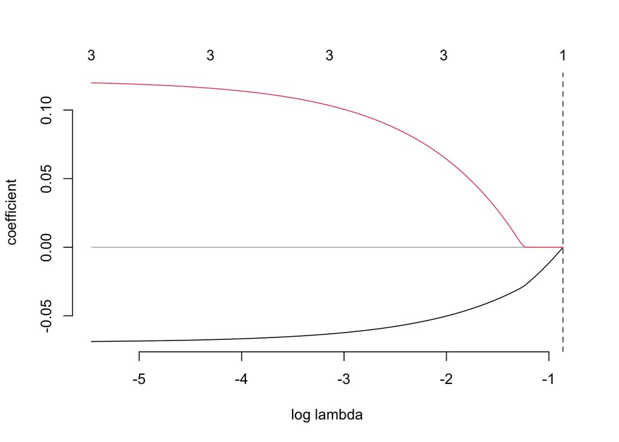

```r
# Plot the new path plot
plot(spender_time)
```

```r
# Compare the path plot to the previous one
```

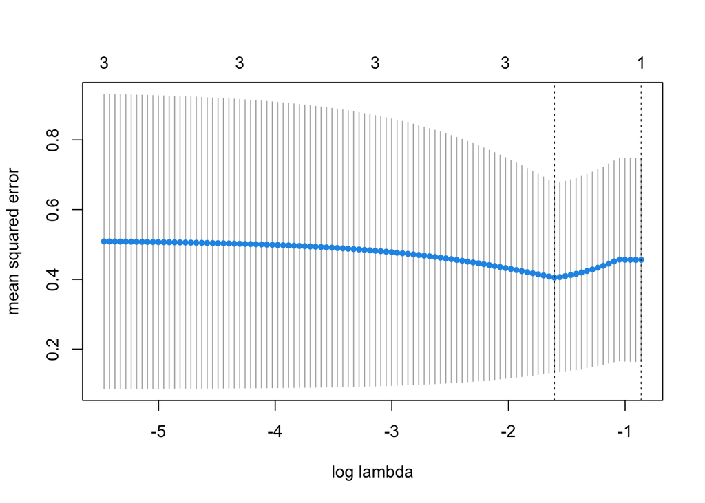

```r
cv.spender <- cv.gamlr(xweb, log(yspend))
plot(cv.spender)
```

How the cross-validation error changes with different lambda values is shown. The optimal lambda is often marked, and it indicates the regularization strength that leads to the best model performance.

```r
betamin = coef(cv.spender, select="min"); betamin
```

```
## 4 x 1 sparse Matrix of class "dgCMatrix"
##                  seg17
## intercept  5.298320666
## Site1     -0.004094101
## Site2      .
## Site3      0.001217182
```

The code betamin = coef(cv.spender, select=“min”) extracts the coefficients from the model selected at the minimum cross-validation error (lambda.min). This step is important because lambda.min represents the regularization parameter value that gives the best model performance according to cross-validation.

We do get different results as each run could create a different split of the data into training and test sets, which could influence the coefficients chosen.

```r
head(AIC(spender))
```

```
##       seg1       seg2       seg3       seg4       seg5       seg6
## -2.7431930 -0.9835934 -1.2207875 -1.4545596 -1.6846880 -1.9109461
```

The code head(AIC(spender)) is used to display the first few rows of the Akaike Information Criterion (AIC) values for the fitted model spender. AIC is a metric used to compare different models; lower AIC values indicate better-fitting models while penalizing for the number of parameters (to avoid overfitting).

By examining the AIC values, you can see how model fit improves (or worsens) as the regularization strength (lambda) changes. You might observe that as you increase lambda (regularization), AIC tends to increase, indicating a worse fit, but at some point, a smaller lambda might overfit the data, and AIC will decrease. Finding the “sweet spot” of lambda can help balance model complexity and fit.